# Project One

Connor Lawson - Darrious Barger

Apr 06, 2020 at 02:18:06 PM

# 1 Data Summary

```r
#view(housing)
```

Using the `view()` command, we can look at all of the raw values in the `Housing` data set.

```r
skim(housing)
```

Table 1.1: Data summary

| Name | housing |
| --- | --- |
| Number of rows | 76 |
| Number of columns | 11 |
| _______________________ |  |
| Column type frequency: |  |
| character | 2 |
| numeric | 9 |
| ________________________ |  |
| Group variables | None |

**Variable type: character**

| skim_variable | n_missing | complete_rate | min | max | empty | n_unique | whitespace |
| --- | --- | --- | --- | --- | --- | --- | --- |
| status | 0 | 1 | 3 | 3 | 0 | 3 | 0 |
| elem | 0 | 1 | 4 | 6 | 0 | 6 | 0 |

**Variable type: numeric**

| skim_variable | n_missing | complete_rate | mean | sd | p0 | p25 | p50 | p75 | p100 | hist |
| --- | --- | --- | --- | --- | --- | --- | --- | --- | --- | --- |
| id | 0 | 1 | 38.50 | 22.08 | 1.00 | 19.75 | 38.50 | 57.25 | 76.0 | ▇▇▇▇▇ |
| price | 0 | 1 | 285.80 | 60.33 | 155.50 | 242.75 | 276.00 | 336.75 | 450.0 | ▂▇▅▅▁ |
| size | 0 | 1 | 1.97 | 0.21 | 1.44 | 1.86 | 1.97 | 2.11 | 2.9 | ▂▇▆▁▁ |
| lot | 0 | 1 | 3.99 | 1.65 | 1.00 | 3.00 | 4.00 | 5.00 | 11.0 | ▃▇▁▁▁ |
| bath | 0 | 1 | 2.21 | 0.57 | 1.00 | 2.00 | 2.00 | 3.00 | 3.1 | ▁▁▇▁▃ |
| bedrooms | 0 | 1 | 3.45 | 0.74 | 2.00 | 3.00 | 3.00 | 4.00 | 6.0 | ▁▇▅▁▁ |
| yearbuilt | 0 | 1 | 1969.41 | 23.49 | 1905.00 | 1957.75 | 1969.50 | 1980.00 | 2005.0 | ▂▁▆▇▅ |
| agestandardized | 0 | 1 | -0.06 | 2.35 | -6.50 | -1.22 | -0.05 | 1.00 | 3.5 | ▂▁▆▇▅ |
| garagesize | 0 | 1 | 1.57 | 0.77 | 0.00 | 1.00 | 2.00 | 2.00 | 3.0 | ▂▂▁▇▁ |

```r
housingOld <- housing
housing$elem <- as.numeric(c("edison" = 0, "adams" = 1, "parker" = 2, "edge" = 3, "harris" = 4, "crest" = 5)[housing$elem])
housing$status <- as.numeric(c("sld" = 0, "pen" = 1, "act" = 2)[housing$status])
```

The `skim()` function lets us analyze the `housing` data set. We can see if any of the data is missing. None of the data seemed to be missing. We did notice that two variables, `status` and `elem`, were characters. We changed them to numeric for data analysis.

```r
sapply(housing, class)
```

```
##              id           price            size             lot            bath
##       "numeric"       "numeric"       "numeric"       "numeric"       "numeric"
##        bedrooms       yearbuilt agestandardized      garagesize          status
##       "numeric"       "numeric"       "numeric"       "numeric"       "numeric"
##            elem
##       "numeric"
```

We used `sapply()` to confirm that `elem` and `status` have been changed to numeric types.

# 2 Exploratory Data Analysis

Below, we examined some of the variable’s relationship with `price`. This information will be useful when building the model.

```r
cor(housing)
```

```
##                          id       price        size         lot        bath
## id               1.00000000  0.04662108  0.27241069 -0.10244192  0.15477558
## price            0.04662108  1.00000000  0.20143783  0.24423228  0.17465777
## size             0.27241069  0.20143783  1.00000000  0.04079199  0.47254061
## lot             -0.10244192  0.24423228  0.04079199  1.00000000 -0.17099609
## bath             0.15477558  0.17465777  0.47254061 -0.17099609  1.00000000
## bedrooms        -0.04912302 -0.28619746  0.23845303 -0.21382977  0.14682576
## yearbuilt        0.22294217  0.15412476  0.17656934 -0.03933975  0.33452385
## agestandardized  0.22294217  0.15412476  0.17656934 -0.03933975  0.33452385
## garagesize       0.03559640  0.35838608  0.17315776  0.23581664  0.20176355
## status           0.07478518  0.25124114 -0.11922561  0.05222278  0.04681522
## elem             0.35036287 -0.04645888  0.14772262 -0.05740613  0.26292541
##                    bedrooms   yearbuilt agestandardized garagesize      status
## id              -0.04912302  0.22294217      0.22294217  0.0355964  0.07478518
## price           -0.28619746  0.15412476      0.15412476  0.3583861  0.25124114
## size             0.23845303  0.17656934      0.17656934  0.1731578 -0.11922561
## lot             -0.21382977 -0.03933975     -0.03933975  0.2358166  0.05222278
## bath             0.14682576  0.33452385      0.33452385  0.2017635  0.04681522
## bedrooms         1.00000000 -0.36315062     -0.36315062 -0.4038039 -0.20454371
## yearbuilt       -0.36315062  1.00000000      1.00000000  0.5371846  0.29966979
## agestandardized -0.36315062  1.00000000      1.00000000  0.5371846  0.29966979
## garagesize      -0.40380395  0.53718464      0.53718464  1.0000000  0.33308182
## status          -0.20454371  0.29966979      0.29966979  0.3330818  1.00000000
## elem            -0.07581527  0.44002292      0.44002292  0.1836038  0.31095128
##                        elem
## id               0.35036287
## price           -0.04645888
## size             0.14772262
## lot             -0.05740613
## bath             0.26292541
## bedrooms        -0.07581527
## yearbuilt        0.44002292
## agestandardized  0.44002292
## garagesize       0.18360377
## status           0.31095128
## elem             1.00000000
```

The `cor()` function was used to look at the corelation values for `price` as they relate to the other variables so that we can see which varibles will be significant in creating a model. Out of all the varibables, `garagesize`, `bedrooms`, `lot`, `size`, and `status` seemed to be the most significant.

It should be noted that the highest correlation value for `price` is `garagesize` at 0.36. This mean all the other correlation values are below 0.36.

## 2.1 Visualzation

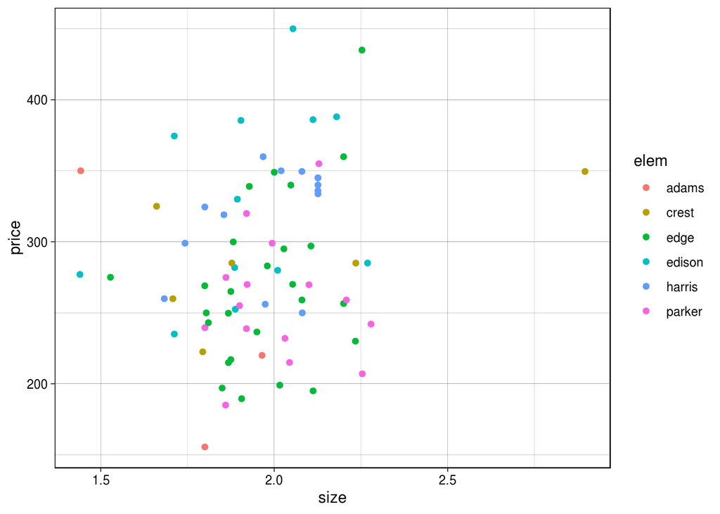

This graph does not show much linearity. All the points are clumped up near the middle.

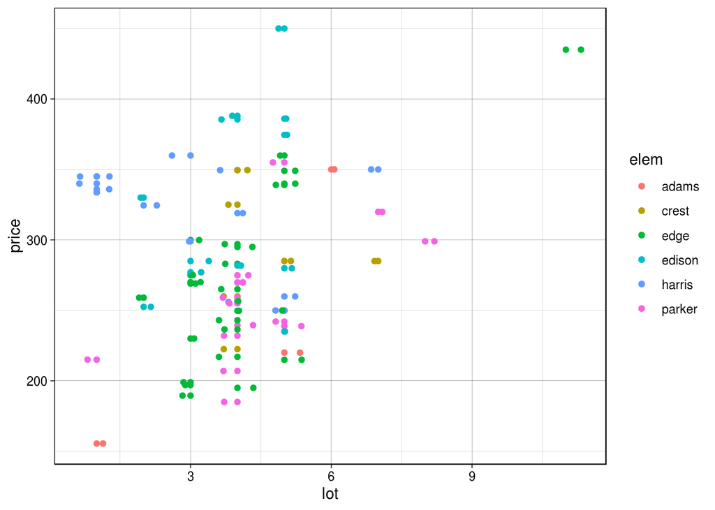

Linearity is improved in this graph but the points are still clumped together, mostly on the left side of the graph.

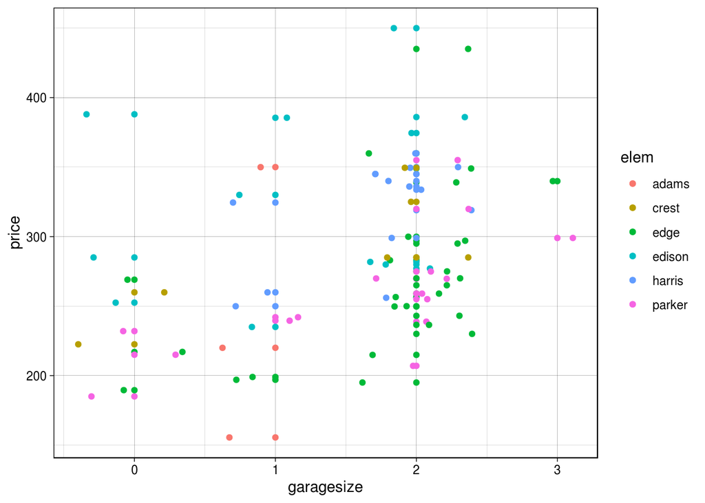

This graph shows us `garagesize` which had the highest correlation coeffication value. Linearity shows a slight improvement in this graph and less clumping.

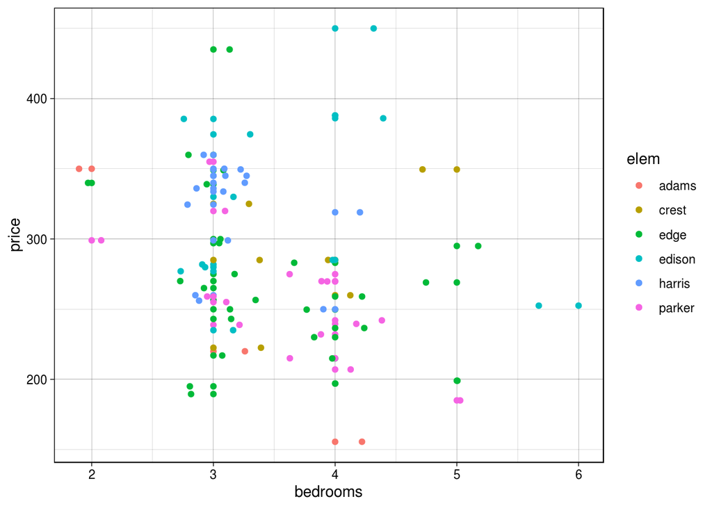

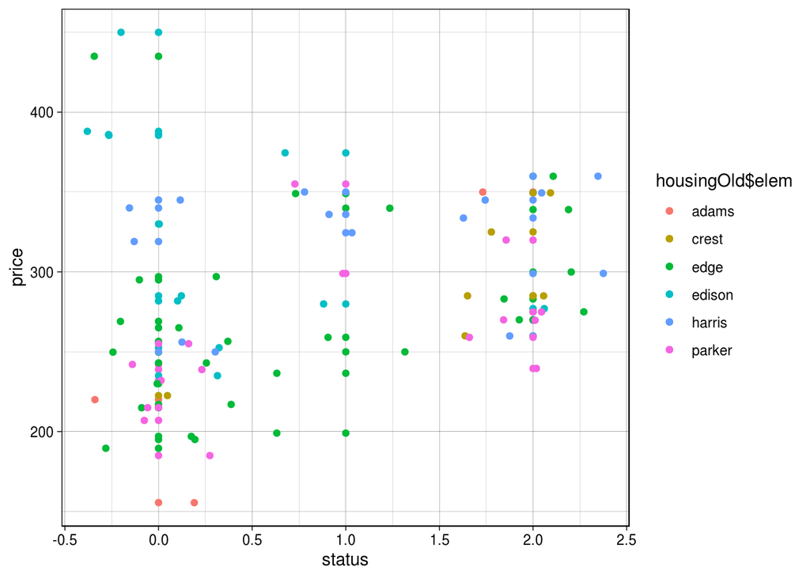

`status` does not show a linear relationship. It is very spread out on the y-axis and gradually gets thinner.

**A note about `elem`**

All the graphs show the `elem` variable using color. On most of the graphs, `edison` (blue) was usually closer to the top while `edge` (green) was usually found near the bottom.

# 3 Intitial Modeling

We built our first regresssion model using `price` and `garagesize`.

```r
house_model = lm(price ~ garagesize, data = housing)
summary(house_model)
```

```
##
## Call:
## lm(formula = price ~ garagesize, data = housing)
##
## Residuals:
##     Min      1Q  Median      3Q     Max
## -114.44  -38.96  -13.96   42.30  152.04
##
## Coefficients:
##             Estimate Std. Error t value Pr(>|t|)
## (Intercept)  241.927     14.791  16.356  < 2e-16 ***
## garagesize    28.017      8.484   3.302  0.00148 **
## ---
## Signif. codes:  0 '***' 0.001 '**' 0.01 '*' 0.05 '.' 0.1 ' ' 1
##
## Residual standard error: 56.7 on 74 degrees of freedom
## Multiple R-squared:  0.1284, Adjusted R-squared:  0.1167
## F-statistic: 10.91 on 1 and 74 DF,  p-value: 0.001479
```

`garagesize` appears to be very significant with a p-value of 0.00148. Our r-squared value (0.1284) is very low.

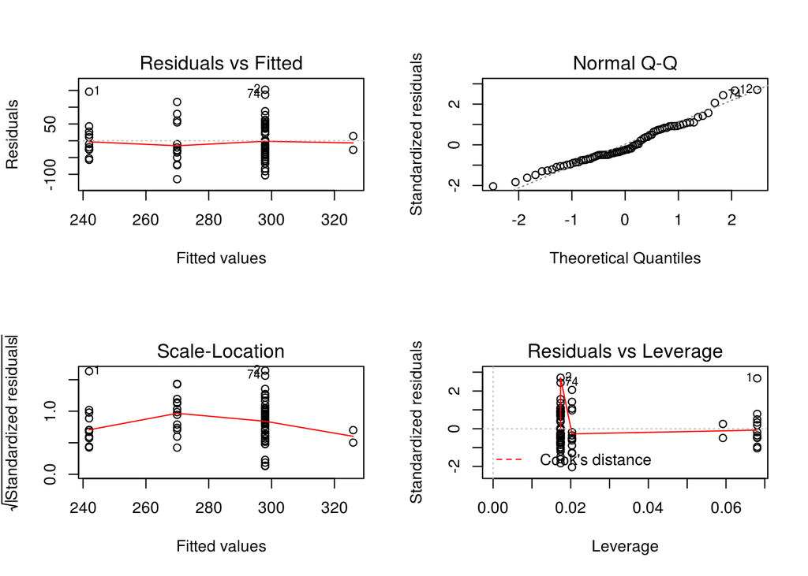

**Residuals vs fitted**

This can detect nonlinearity (primarily) and non constant variation of errors. Curvature in the line is bad.

Overall, this graph looks good. There is some slight curvature but it is mostly straight.

**Normal Q-Q**

This can detect non-normality of the residuals. We want all the points to follow a straight line.

This graph looks ok in the center but the points curve off at the beginning and end.

**Scale Location**

We see a decreasing trend in the graph. This means we have unequal variance.

**Residuals vs leverage**

This shows us the aamount of impact a point pontentially has on the fitted regression line. Due to the nature of the `garagesize` variable (values will be 0, 1, 2, or 3), this graph is very hard to read.

# 4 Model Modification

We added `size` and applied a power transformation to `bedrooms`.

```r
house_model2 = lm(price ~ garagesize + size + bedrooms + I(bedrooms^2), data = housing)
summary(house_model2)
```

```
##
## Call:
## lm(formula = price ~ garagesize + size + bedrooms + I(bedrooms^2),
##     data = housing)
##
## Residuals:
##      Min       1Q   Median       3Q      Max
## -116.631  -39.229   -7.227   36.178  167.855
##
## Coefficients:
##               Estimate Std. Error t value Pr(>|t|)
## (Intercept)    316.278    119.070   2.656  0.00975 **
## garagesize      16.965      9.468   1.792  0.07741 .
## size            67.340     32.588   2.066  0.04244 *
## bedrooms       -86.280     60.554  -1.425  0.15858
## I(bedrooms^2)    8.671      7.880   1.100  0.27487
## ---
## Signif. codes:  0 '***' 0.001 '**' 0.01 '*' 0.05 '.' 0.1 ' ' 1
##
## Residual standard error: 55.16 on 71 degrees of freedom
## Multiple R-squared:  0.2087, Adjusted R-squared:  0.1641
## F-statistic: 4.681 on 4 and 71 DF,  p-value: 0.002071
```

`bedroom` is not sigficant. With the new model, `garagesize` has become far less significant while `size` is significant with a p-value of 0.042. The r-squared value was raised slighlty to 0.2087 from 0.1284.

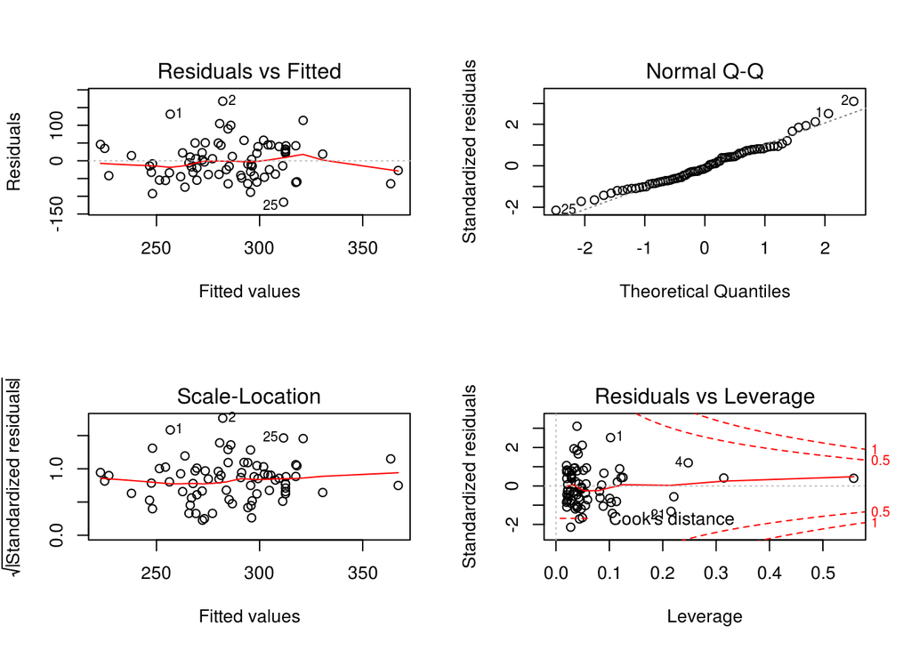

**Residuals vs fitted**

This graph has gotten worse with the new changes. There is more curvature in the line.

**Normal Q-Q**

This graph has improved. The curvature around the edges has been flattened and the line is traighter

**Scale Location**

This line looks a little better. The line shows a slight increasing trend but is fairly straight.

**Residuals vs leverage**

There are a few points that may have high influence (1, 4). There is one point with a very large amount of leverage.

# 5 Conclusions

Below is our multiple regresson model.

$$price = 316.278 + 16.965 * garagesize + 67.340 * size - 86.280 * bedrooms + 8.671 * bedrooms ^ 2$$

In the previous section, we saw an improvement in some of the `plot()` graphs. The r-squared value was increased with our model modification; however, it was not as high as we would have liked it to be.

```r
confint(house_model2)
```

```
##                     2.5 %    97.5 %
## (Intercept)     78.858806 553.69717
## garagesize      -1.912701  35.84270
## size             2.362037 132.31786
## bedrooms      -207.021027  34.46011
## I(bedrooms^2)   -7.041189  24.38401
```

We used confint() command to look at all the confindence interval for the $\beta$ values in our model.

## 5.1 Mean 95% response interval

```r
mean_resp <- data.frame(garagesize = mean(housing$garagesize), size = mean(housing$size), bedrooms = mean(housing$bedrooms))
mean_resp
```

```
##   garagesize     size bedrooms
## 1   1.565789 1.970395 3.447368
```

```r
p = predict(house_model2, mean_resp, interval = "confidence")
p
```

```
##        fit      lwr      upr
## 1 281.1414 265.9661 296.3167
```

The mean 95% confindence interval for the price of a house is between 265.9661 and 296.3167 hundred thousand dollars.

## 5.2 95% prediction

```r
newdata <- data.frame(garagesize = 4, size = 3.025, bedrooms = 4)
```

```r
predict(house_model2, newdata, interval = "predict")
```

```
##        fit      lwr     upr
## 1 381.4621 250.3211 512.603
```